# Microeconomics 1021A

18/09/2020

## Content

- Problems 11, 13, 14, 20 (p.55)

**Key terms**

- Production possibilities frontier (PPF)
- Production efficiency
- Opportunity cost
- Allocative efficiency
- Marginal cost
- Marginal benefit
- Comparative advantage

## Problem 2.11

Suppose that Yucatan’s production possibilities are:

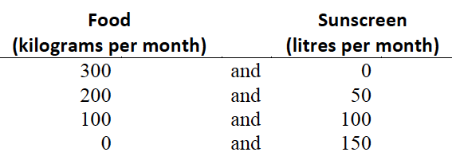

## Problem 2.11

1. Draw a graph of Yucatan’s PPF and explain how your graph illustrates a tradeoff.
2. If Yucatan produces 150 kilograms of food per month, how much sunscreen must it produce if it achieves production efficiency?
3. What is Yucatan’s opportunity cost of producing (i) 1 kilogram of food and (ii) 1 litre of sunscreen?
4. What is the relationship between your answers to part (c)?

## Problem 2.11

## Problem 2.11

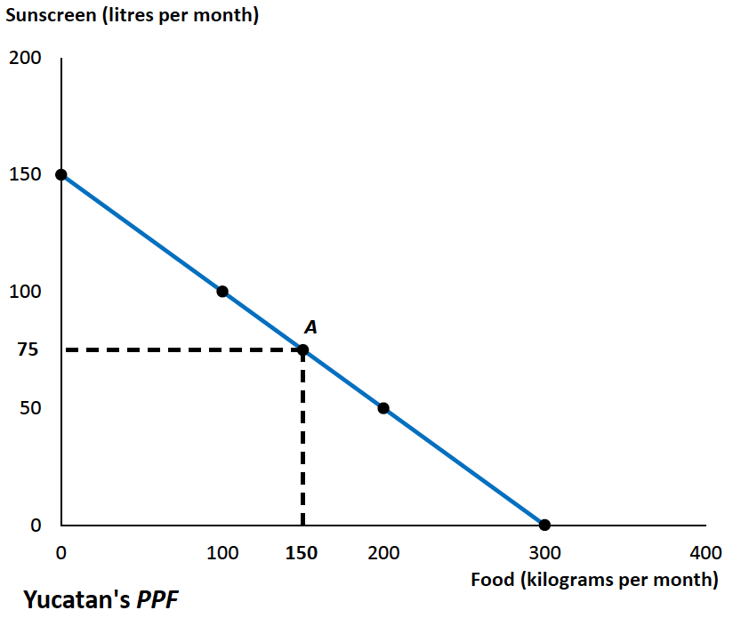

## Problem 2.13 SOLUTION

- The marginal cost of 1 kilogram of food in Yucatan is **constant** at all points along Yucatan’s PPF and is equal to 0.5 litres of sunscreen per kilogram of food.
- Constant marginal cost = linear PPF.

## Problem 2.14

The table describes the preferences in Yucatan.

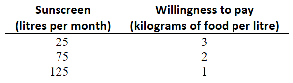

## Problem 2.14

1. What is the marginal benefit from sunscreen and how is it measured?
2. Using the table from Problem 2.11, what does Yucatan produce to achieve allocative efficiency?

## Problem 2.14 SOLUTION

1. The marginal benefit from sunscreen is the **benefit enjoyed by the person who consumes 1 more** litre of sunscreen. It is equal to the willingness to pay for an additional litre.
2. Allocative efficiency = Yucatan is **producing at the point on the PPF that is most preferred.**: MB = MC.

MC of 1 L of sunscreen = 2 kg of food.

\(\implies\) MB = 2.

\(\implies\) Yucatan should produce 75 L of sunscreen.

\(\implies\) to be at the PPF, Yucatan must produce 150 kg of food.

## Problem 2.20

Tony and Patty produce skis and snowboards. The tables show their production possibilities. Each week, Tony produces 5 snowboards and 40 skis; Patty produces 10 snowboards and 5 skis.

## Problem 2.20

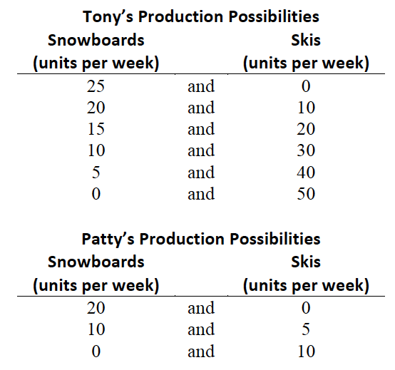

## Problem 2.20

1. Who has the comparative advantage in producing (i) snowboards and (ii) skis?
2. If Tony and Patty specialize and trade 1 snowboard for 1 ski, what are the gains from trade?

## Problem 2.20 SOLUTIONS

1. The worker who has the comparative advantage in producing snowboards is the one who has the **lowest opportunity cost** of producing 1 snowboard.

Tony: 1 snowboard: 2 skis Patty: 1 snowboard: 0.5 skis

\(\implies\) Patty has the lower opportunity cost

\(\implies\) Patty has the comparative advantage of producing snowboards.

## Problem 2.20 SOLUTIONS

1. Gains from trade. \(20-15= 5 SB\); \(50-45= 5 Skis\)

Currently,

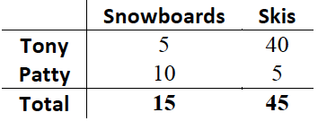

If Tony and Patty specialize and trade,

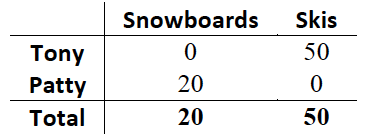

## Recap

- Production efficiency is achieved at the PPF.
- The PPF illustrates graphically the opportunity cost of producing one good in terms of the other.
- Constant marginal cost = Linear PPF.
- Allocative efficienty is achieved at the PPF point that is most preferred. MB = MC.
- Comparative advantage = lowest opportunity cost.